# tools

## [标识符-matplotlib.markers](https://matplotlib.org/stable/api/markers_api.html)

可以在绘图函数内通过`marker="marker name"`设置标识符， 标识符大小通过`markersize1=<16>`设置。

下面是一些常用的`marker name`

| marker | symbol | description |
| --- | --- | --- |
| “.” |  | point |
| “,” |  | pixel |
| “o” |  | circle |
| “v” |  | triangle_down |
| “^” |  | triangle_up |
| “<” |  | triangle_left |
| “>” |  | triangle_right |
| “1” |  | tri_down |
| “2” |  | tri_up |
| “3” |  | tri_left |
| “4” |  | tri_right |
| “8” |  | octagon |
| “s” |  | square |
| “p” |  | pentagon |
| “P” |  | plus(filled) |
| “*” |  | star |
| “h” |  | hexagon1 |
| “H” |  | hexagon2 |
| “+” |  | plus |
| “x” |  | x |
| “X” |  | x(filled) |
| “D” |  | diamond |
| “d” |  | thin_diamond |
| “\|” |  | vline |
| “_” |  | hline |

## [颜色-matplotlib.colors](https://matplotlib.org/stable/gallery/color/named_colors.html)

颜色的控制参数为`color="color name"`，`color name`有很多形式，包括 1. 单字母：

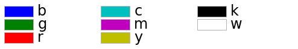

2. 单词：

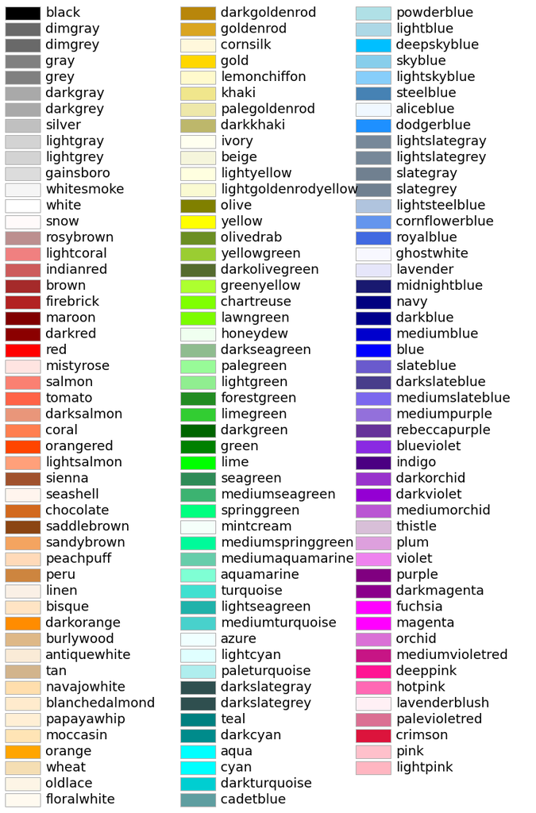

3. 六位十六进制颜色值

- #ff0094
- #ff0000
- #000000

## [颜色映射-colormap](https://matplotlib.org/stable/gallery/color/colormap_reference.html)

颜色映射的控制参数为`cmap="colormap name"`，常用的`colormap name`为

- `jet`: `ANSYS Fluent`默认选项
- `coolwarm`: `Paraview`默认选项
- `hot`: `Comsol`默认选项
- `Greys` or `gray`: 灰度
- `binary`: 黑白二值
- 所以`colormapname`均支持`colormapname_r`来反转

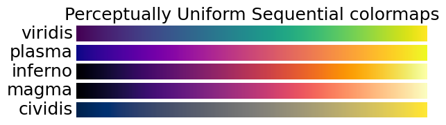

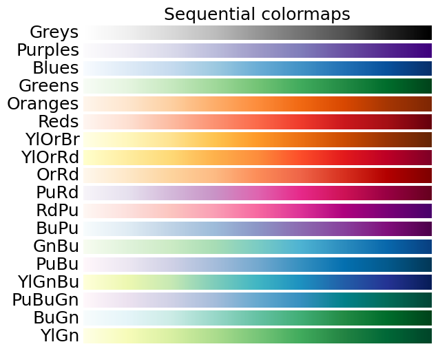

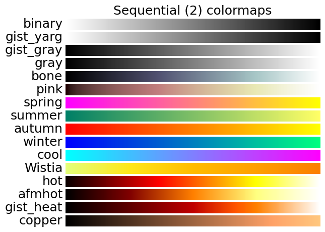

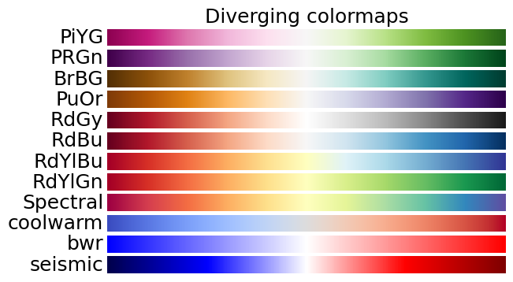

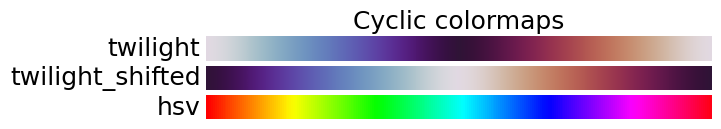

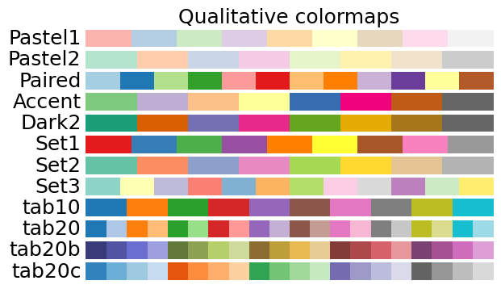

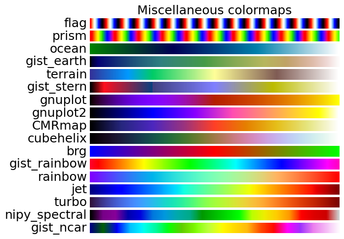

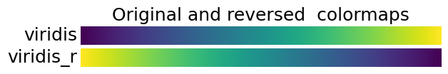

## [线形-linestyles](https://matplotlib.org/stable/gallery/lines_bars_and_markers/linestyles.html)

线型参数可以通过`linestyle="linestyle name"`设置， 线宽控制为`linewidth=<2>` or `lw=<2>` 常用的`linestyle name`为：

- `solid` 实线
- `dotted` 点线
- `dashed` 虚线
- `dashdot` 点画线

下面是一些效果，

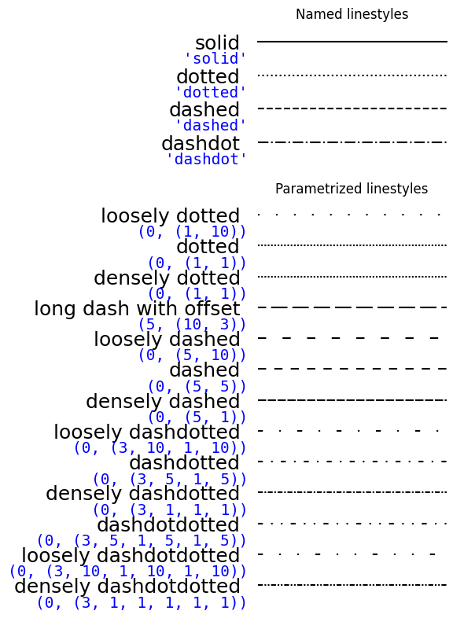

## [剖面线-matplotlib.hatch](https://matplotlib.org/stable/gallery/shapes_and_collections/hatch_style_reference.html)

可以在一些绘图函数中通过`hatch`参数指定`patch`对象的填充值， 这一点在一些[条形图](https://matplotlib.org/stable/gallery/shapes_and_collections/hatch_demo.html)中常用于区分不同组数据。

以下是`hatch`参数的一些可选值 1. 单个字符决定样式

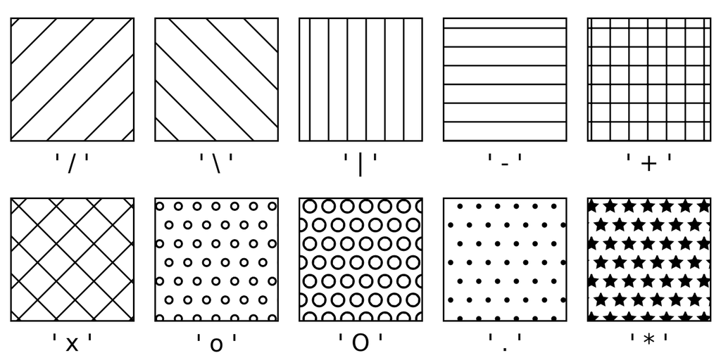

2. 重复字符可以增加密度

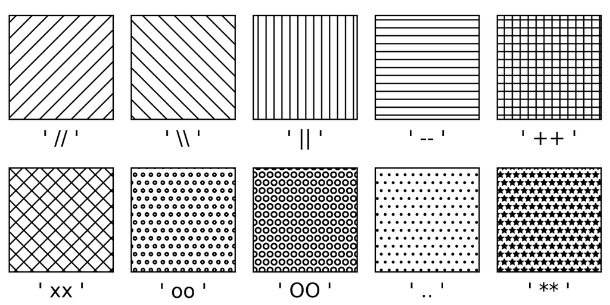

3. 组合字符可以组合样式

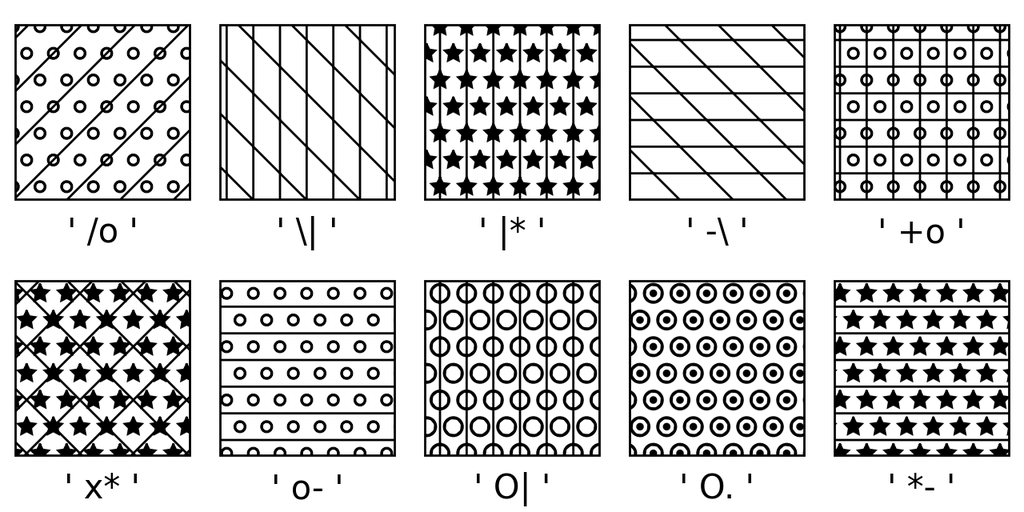

## [绘图样式-matplotlib.style](https://matplotlib.org/stable/gallery/style_sheets/style_sheets_reference.html)

可以使用`plt.style.use('bmh')`设置相应的风格， 其中风格字符串名可以使用`print(plt.style.available)`打印， 安装一些库（例如`pip install SciencePlots`）后可以使用更多风格。

以下时一些内置风格。

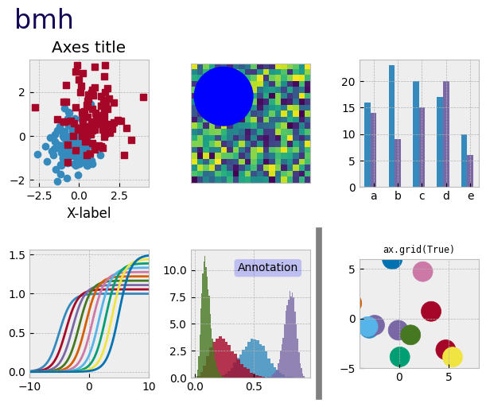

[figure not shown]

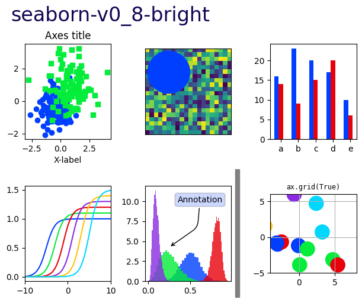

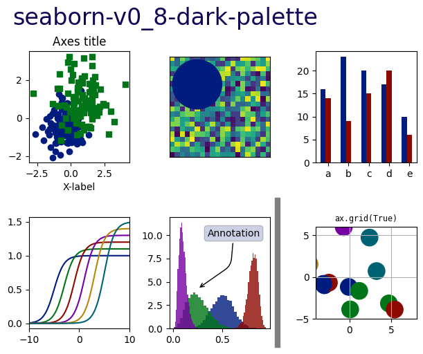

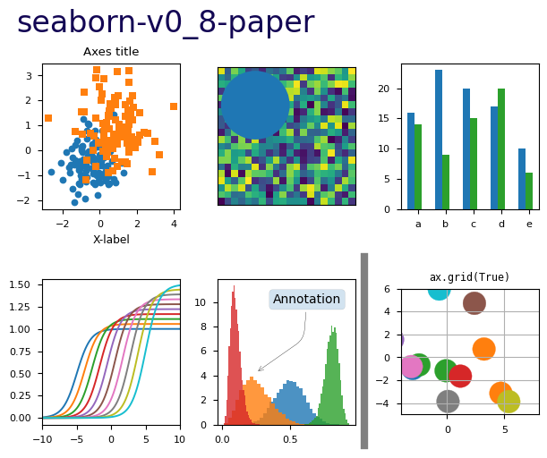

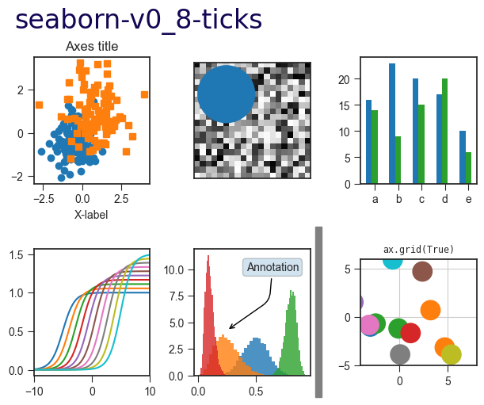

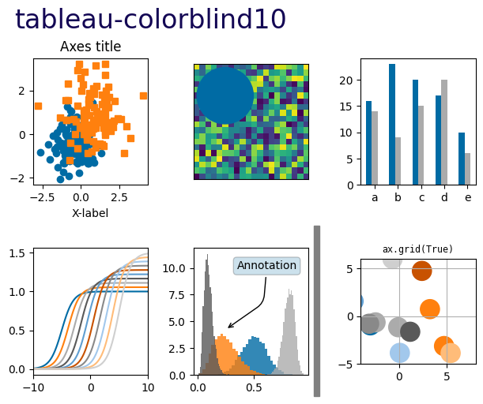

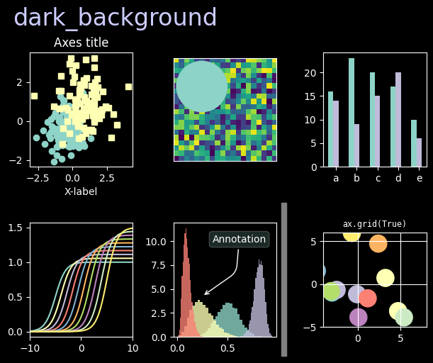

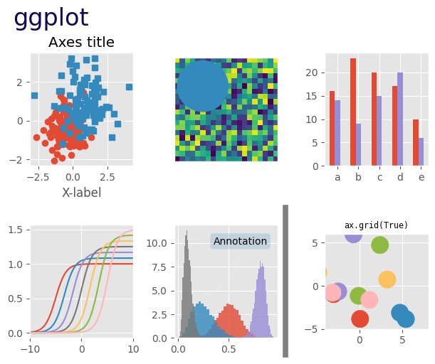

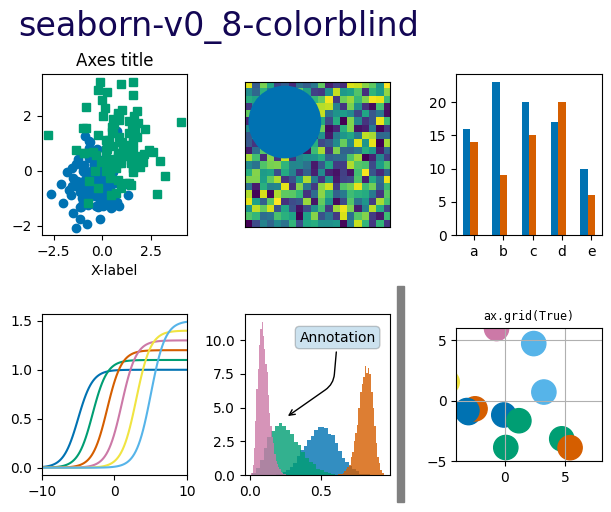

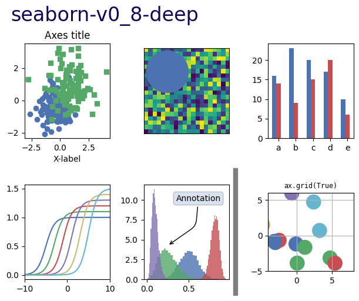

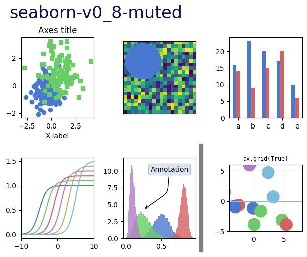

[13 more figures not shown]